# Random walk

Examine dependence across periods in firms’ sales growth rates. Select firms using beginning-of-period sales, firm age, and industry conditions for 2010–11, and calculate Spearman rank correlations among the ten periods from 2010–11 through 2019–20. Also use growth rates in 2010–11 and 2011–12 to calculate a tail dependence measure and the cumulative mean of the following period’s growth after transforming it to nonnegative values.

## 1 Rank correlations of growth rates

```r
library(tidyverse)
library(pins)
library(hrbrthemes)
library(kableExtra)
theme_set(theme_ipsum(base_size = 12, axis_title_size = 13))
board <- board_folder("../Zipf_law_board_replicate_simulation")
```

**Setting sample conditions**

Load `sample_growth_tb` and calculate firm age `age` as the beginning year extracted from period label `year` minus establishment year `birth_year`. For 2010–11 growth records (`g_11_10`), save the `id` values of firms meeting the following conditions in `id_tb`.

- Beginning-of-period sales `pre_sale` of at least $4.0 \times 10^4$  
  With sales measured in thousands of yen, this corresponds to at least 40 million yen.
- Beginning-of-period firm age of at least five
- The first two digits of industry code `ind_class` are 01–61 or 68–92

Use this set of firms for both rank correlations and tail analyses.

Define `pobs()` to transform growth rates into rank-based pseudo-observations. Use average ranks for ties and divide by the length of the original vector plus one.

```r
library(corrr)
library(scattermore)

pobs <- function(x) {
  rank(x, ties.method = "average", na.last = "keep") / (length(x) + 1)
}

sample_growth_tb <- board |> pin_read("sample_growth_tb", type = "qs2") |>
  mutate(age = as.numeric(str_c(20, str_sub(year, 6,7))) - birth_year)

id_tb <- sample_growth_tb |>
  filter(year == "g_11_10",
         pre_sale >= 4.0*10^4,
         age >= 5,
         str_sub(ind_class, 1,2) %in% str_pad(c(1:61, 68:92), 2, pad = 0)) |>
  distinct(id)
```

**Data for the two-period tail analysis**

Extract growth rates for 2011–12 (`g_12_11`) and 2010–11 (`g_11_10`), retaining only firms with finite growth rates in both periods in `normal_tb`. Exclude `NA`, `NaN`, and positive or negative infinity. Transform growth in each period to ranks separately using `pobs()`.

```r
normal_tb <- sample_growth_tb |>
  pivot_wider(id_cols = id, names_from = "year", values_from = "growth") |>
  inner_join(id_tb, by = "id") |>
  select(g_12_11, g_11_10) |>
  filter(is.finite(g_12_11), is.finite(g_11_10)) |>
  mutate(pobs_12_11 = pobs(g_12_11), pobs_11_10 = pobs(g_11_10))
```

**Spearman rank correlations across ten periods**

Calculate the Spearman rank correlation matrix for firms in `id_tb`. At this stage, require a common sample with finite growth rates in all ten periods.

```r
spearman_mat_tb <- sample_growth_tb |>
  filter(year %in% c("g_20_19", "g_19_18", "g_18_17", "g_17_16", "g_16_15",
                     "g_15_14", "g_14_13", "g_13_12", "g_12_11", "g_11_10")) |>
  select(id, year, growth) |>
  pivot_wider(id_cols = id, names_from = "year", values_from = "growth") |>
  inner_join(id_tb, by = "id") |>
  select(-id) |>
  filter(if_all(everything(), is.finite)) |>
  correlate(method = "spearman")
spearman_mat_tb
```

| term | g_20_19 | g_19_18 | g_18_17 | g_17_16 | g_16_15 | g_15_14 | g_14_13 | g_13_12 | g_12_11 | g_11_10 |
| --- | --- | --- | --- | --- | --- | --- | --- | --- | --- | --- |
| g_20_19 | NA | -1.969767e-05 | 0.0014315382 | -3.700285e-05 | -0.0052950524 | -0.0008544730 | -0.0006918436 | -0.0073861762 | -0.001574023 | 0.0039906416 |
| g_19_18 | -1.969767e-05 | NA | -0.0002347367 | -2.086249e-03 | 0.0010639168 | -0.0008668783 | 0.0012586291 | -0.0002769644 | 0.001669220 | 0.0035103388 |
| g_18_17 | 1.431538e-03 | -2.347367e-04 | NA | -1.898322e-03 | 0.0002912587 | 0.0017179854 | 0.0017535143 | 0.0022282703 | 0.002515481 | -0.0028281145 |
| g_17_16 | -3.700285e-05 | -2.086249e-03 | -0.0018983217 | NA | 0.0014377540 | -0.0008315538 | 0.0012758032 | 0.0014319447 | -0.001279927 | 0.0036045800 |
| g_16_15 | -5.295052e-03 | 1.063917e-03 | 0.0002912587 | 1.437754e-03 | NA | -0.0070084414 | 0.0008161474 | 0.0006251557 | -0.002295167 | -0.0038555906 |
| g_15_14 | -8.544730e-04 | -8.668783e-04 | 0.0017179854 | -8.315538e-04 | -0.0070084414 | NA | 0.0055456211 | 0.0005876650 | -0.005456949 | 0.0006177214 |
| g_14_13 | -6.918436e-04 | 1.258629e-03 | 0.0017535143 | 1.275803e-03 | 0.0008161474 | 0.0055456211 | NA | -0.0011249482 | 0.003170335 | -0.0001524938 |
| g_13_12 | -7.386176e-03 | -2.769644e-04 | 0.0022282703 | 1.431945e-03 | 0.0006251557 | 0.0005876650 | -0.0011249482 | NA | 0.001550366 | -0.0048704613 |
| g_12_11 | -1.574023e-03 | 1.669220e-03 | 0.0025154812 | -1.279927e-03 | -0.0022951671 | -0.0054569486 | 0.0031703354 | 0.0015503655 | NA | 0.0012382011 |
| g_11_10 | 3.990642e-03 | 3.510339e-03 | -0.0028281145 | 3.604580e-03 | -0.0038555906 | 0.0006177214 | -0.0001524938 | -0.0048704613 | 0.001238201 | NA |

## 2 Dependence in the tail

**Tail dependence measure**

Let $N$ be the number of firms in `normal_tb` and $N_q$ the number whose pseudo-observations strictly exceed threshold $q$ in both periods. Calculate the tail dependence measure as $N_q/[N(1-q)]$. Vary $q$ from 0.8 to 0.9995 in increments of 0.0005.

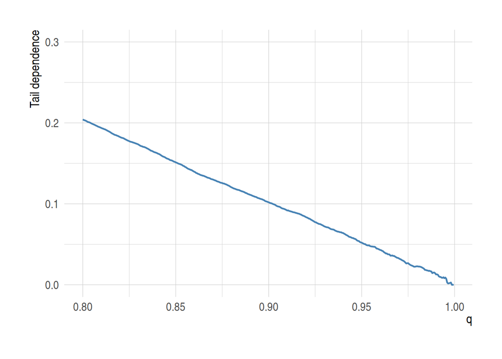

```r
tail_tb <- seq(0.8, 0.9995, by = 0.0005) |>
  map_dfr(~ normal_tb |>
            filter(pobs_12_11 > .x, pobs_11_10 > .x) |>
            summarise(criteria = .x,
                      tail_coeff = (n()/nrow(normal_tb))/(1 - .x))
          )

tail_tb |>
ggplot(aes(criteria, tail_coeff)) +
  geom_line(size = 0.8, color = "steelblue") +
  ylim(0, 0.3) +
  labs(x = expression(q),
       y = "Tail dependence") +
  theme(axis.title = element_text(face = "bold"))
ggsave(filename = "tail_coeff_TSR.png", path = "graph")
```

**Cumulative mean of nonnegative growth in the following period**

Sort `normal_tb` by descending growth in 2010–11, transform growth in the following period (2011–12) to $\max(g_{12,11}, 0)$, and calculate its cumulative mean. Plot 2010–11 growth $t$ on the horizontal axis and the cumulative mean of nonnegative growth in the following period on the vertical axis to examine subsequent growth among firms that experienced large growth. Calculate cumulative means using all of `normal_tb`, restricting only the displayed horizontal range to 0.2–2 and vertical range to 0–0.5.

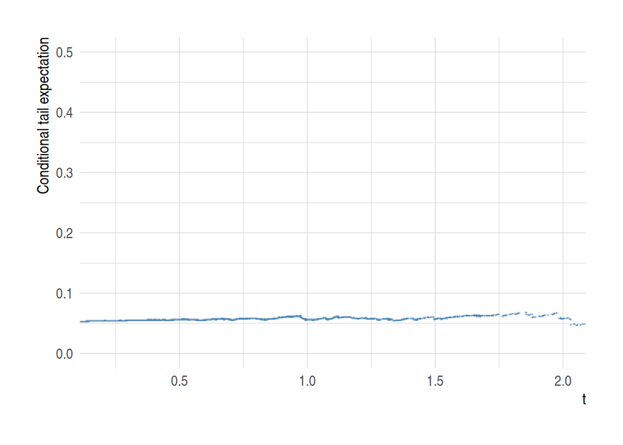

```r
normal_tb |>
  arrange(desc(g_11_10)) |>
  mutate(
    g_12_11 = if_else(g_12_11 > 0, g_12_11, 0),
    cummean_12_11 = cummean(g_12_11)
  ) |>
ggplot(aes(g_11_10, cummean_12_11)) +
  geom_scattermore(pointsize = 1.5, color = "steelblue") +
  coord_cartesian(xlim = c(0.2, 2), ylim = c(0, 0.5)) +
  labs(x = "t",
       y = "Conditional tail expectation") +
  theme(axis.title = element_text(face = "bold"))
ggsave(filename = "cond_tail_expect_g_11_10_transformed.png", path = "graph")
```

## 3 LaTeX table output

Save the rank correlation matrix `spearman_mat_tb` to `latex/spearman_mat.tex` in the same folder as this QMD. Display missing values as `--`, including those on the diagonal.

```r
# Leave the original correlation matrix unchanged and format a copy for output.
spearman_for_tex <- as.data.frame(spearman_mat_tb)
spearman_for_tex[[1]] <- str_replace(
  spearman_for_tex[[1]], "^g_(\\d{2})_(\\d{2})$", "20\\2--\\1"
)
period_labels <- str_replace(
  names(spearman_for_tex)[-1], "^g_(\\d{2})_(\\d{2})$", "20\\2--\\1"
)

# Prevent line breaks within period labels in row and column headings.
spearman_for_tex[[1]] <- paste0(
  "\\mbox{", spearman_for_tex[[1]], "}"
)
period_labels <- paste0("\\mbox{", period_labels, "}")

for (column in names(spearman_for_tex)[-1]) {
  spearman_for_tex[[column]] <- ifelse(
    is.na(spearman_for_tex[[column]]),
    "--",
    sprintf("%.3f", spearman_for_tex[[column]])
  )
}

spearman_tex <- spearman_for_tex |>
  kbl(
    format = "latex",
    booktabs = TRUE,
    row.names = FALSE,
    escape = FALSE,
    align = c("l", rep("r", length(period_labels))),
    col.names = c("Year", period_labels),
    linesep = ""
  ) |>
  kable_styling(
    latex_options = "striped",
    stripe_color = "gray!10",
    stripe_index = which(seq_len(nrow(spearman_for_tex)) %% 2L == 1L),
    full_width = TRUE,
    position = "left",
    font_size = 9
  )

writeLines(
  c(
    "\\begingroup",
    "\\setlength{\\tabcolsep}{0.5pt}",
    "\\renewcommand{\\arraystretch}{1.12}",
    "\\setlength{\\aboverulesep}{0.5ex}",
    "\\setlength{\\belowrulesep}{0.5ex}",
    "\\setlength{\\heavyrulewidth}{0.8pt}",
    "\\setlength{\\lightrulewidth}{0.4pt}",
    as.character(spearman_tex),
    "\\endgroup"
  ),
  con = file.path("latex", "spearman_mat.tex"),
  useBytes = TRUE
)
```